# Some Experiments with the Northamptonshire County Datasets

Anshuman Kanetkar

## 1 Introduction

This IPython notebook outlines some experiments with the static datasets on the Northamptonshire County Council website. It also steps you through using the `DataFetcher` helper class, written in Python, which provides an API to:

- Navigate the dataset hierarchy,
- Download data files from the website, and
- Load them into memory for data analysis using Python data analysis tools.

First we need to import the third-party packages we will need. These are:

- **pandas** - For spreadsheet-style data frames
- **matplotlib** - To generate inline graphs. The %matplotlib magic command enables plotting in the current Notebook, and the 'inline' directive embeds graphs directly in the notebook.

```python
import os
import pandas as pd
%matplotlib inline
import matplotlib.pyplot as plt
import re
```

Then, we import the `DataFetcher` helper class from the `analysis.datafetch.northants` module.

```python
from analysis.datafetch.northants import DataFetcher
```

## 2 Accessing the Data

The DataFetcher class provides methods to access the datasets provided by the Northamptonshire County Council. The data seems to be organized in the following hierarchy:

- **Themes** : These are broad areas of interest under which the various datasets have been organized. Some prominent examples:
  - Population & Census
  - Education
  - Economy

  Each theme has a unique id which is used in organizing the namespace for the website. The Datafetcher uses this to navigate around the site's various parts.
- **Sub-themes** : These are further refinements of the individual themes -- for instance, *Age & Gender* datasets within the *Population & Census* theme.
- **Dataviews** : Each data collection is called a *DataView* -- all files with the same *dataview id* have the same layout (ie columns), though they may be collected over different regions.
- **geo ids & names** : As mentioned before a *DataView* could have multiple datasets collected over different target areas, for instance, population data collected at the county, district or country level etc.

## 3 Initializing the DataFetcher API

First, we need to instantiate a DataFetcher object as follows:

```python
fd = DataFetcher()
```

Then this newly created `DataFetcher` object needs to be configured before use -- either by loading a previously saved configuration, or by querying the website. The relevant methods for doing this are:

- `sync_metadata()` : This method fetches the *metadata* from the county website. The metadata is needed to navigate throught the dataset hierarchy and to organize the data when it is downloaded.
- `save_metadata(file_name)` : Saves the *metadata* in the given file in JSON format.
- `load_metadata(file_name)` : This method loads the JSON-encoded *metadata* that we may have saved previously with `save_metadata()`

```python
if os.path.exists('metadata.json'):
    fd.load_metadata('metadata.json')
else:
    fd.sync_metadata()
    fd.save_metadata('metadata.json')
```

## 4 Understanding the datasets

As the the example below shows the dict returned by `get_dataview_ids_with_details` can be loaded directly into a pandas DataFrame.

```python
dataviews = fd.get_dataview_ids_with_details()
dvdf = pd.DataFrame(dataviews).transpose().sort(['theme'])
dvdf
```

|  | description | subtheme | theme | title |
| --- | --- | --- | --- | --- |
| 199 | Residents who provide unpaid care to others by... | ASC1: Carers | Adult Social Care | Census : Residents Providing Unpaid Care |
| 54 | Live Births, Fertility Rates, Infant Mortality... | C&YP: Early Years and Children's Centres | Children and Young People | Live Births & Infant Death |
| 112 |  | C&YP: Children's Health | Children and Young People | Child Immunisations |
| 114 |  | C&YP: Children's Social Care Caseload | Children and Young People | Looked after children |
| 115 |  | C&YP: Children's Social Care Caseload | Children and Young People | Looked after Asylum Seekers children |
| 163 | Results of the Departments of Health and Educa... | C&YP: Children's Health | Children and Young People | Childhood Obesity |
| 191 | % of all Foundation Stage pupils in schools (a... | C&YP: School Achievement / Examination Results | Children and Young People | Achievement in Foundation Stage Profile (Acade... |
| 192 | % of those deemed "End of Key Stage 4" who ach... | C&YP: School Achievement / Examination Results | Children and Young People | Achievement at Key Stage 4 GCSE |
| 211 | Young people (Under Age 24) claiming Job Seeke... | C&YP: Youth Employment and Unemployment | Children and Young People | Youth Unemployment |
| 230 | Children in Low Income Families Local Measure ... | C&YP: Deprivation | Children and Young People | Children in Low Income Families Local Measure ... |
| 250 | Characteristics of Young People 10-17 who offe... | C&YP: Young People Who Offend | Children and Young People | Young People Who Offend : Characteristics |
| 251 | Outcomes/Disposals received by a young person ... | C&YP: Young People Who Offend | Children and Young People | Young People Who Offend : Outcomes/Disposals (... |
| 252 | Outcomes/Disposals received by a young person ... | C&YP: Young People Who Offend | Children and Young People | Young People Who Offend : Outcomes/Disposals (... |
| 253 | Outcomes/Disposals received by a young person ... | C&YP: Young People Who Offend | Children and Young People | Young People Who Offend : Outcomes/Disposals (... |
| 254 | Outcomes/Disposals received by a young person ... | C&YP: Young People Who Offend | Children and Young People | Young People Who Offend : Outcomes/Disposals (... |
| 255 | Outcomes/Disposals received by a young person ... | C&YP: Young People Who Offend | Children and Young People | Young People Who Offend : Outcomes/Disposals (... |
| 256 | Outcomes/Disposals received by a young female ... | C&YP: Young People Who Offend | Children and Young People | Young People Who Offend : Outcomes/Disposals (... |
| 257 | Outcomes/Disposals received by a young male pe... | C&YP: Young People Who Offend | Children and Young People | Young People Who Offend : Outcomes/Disposals (... |
| 258 | % of young people receiving the four main cate... | C&YP: Young People Who Offend | Children and Young People | Young People Who Offend : % Outcome Categories... |
| 259 | Outcomes/Disposals received by a young person ... | C&YP: Young People Who Offend | Children and Young People | Young People Who Offend : Outcomes/Disposals (... |
| 260 | Average Number of Outcomes per young person wh... | C&YP: Young People Who Offend | Children and Young People | Young People Who Offend : Average Number of Ou... |
| 261 | Outcomes/Disposals received by a young person ... | C&YP: Young People Who Offend | Children and Young People | Young People Who Offend : Outcomes/Disposals (... |
| 262 | Outcomes/Disposals received by a young person ... | C&YP: Young People Who Offend | Children and Young People | Young People Who Offend : Outcomes/Disposals (... |
| 263 | Outcomes/Disposals received by a young person ... | C&YP: Young People Who Offend | Children and Young People | Young People Who Offend : Outcomes/Disposals (... |
| 264 | Outcomes/Disposals received by a young person ... | C&YP: Young People Who Offend | Children and Young People | Young People Who Offend : Outcomes/Disposals (... |
| 265 | Outcomes/Disposals received by a young person ... | C&YP: Young People Who Offend | Children and Young People | Young People Who Offend : Outcomes/Disposals (... |
| 266 | Outcomes/Disposals received by a young person ... | C&YP: Young People Who Offend | Children and Young People | Young People Who Offend : Outcomes/Disposals (... |
| 269 | Achievement in Foundation Stage Profile (data ... | C&YP: School Achievement / Examination Results | Children and Young People | Achievement in Foundation Stage Profile (data ... |
| 270 | Results of the Oral Health Survey (dental deca... | C&YP: Children's Health | Children and Young People | Oral Health / Dental Decay Amongst 5 Year Olds |
| 275 | Population of children ages 0-4 years | C&YP: Early Years and Children's Centres | Children and Young People | Early Years (0-4s) Population |
| ... | ... | ... | ... | ... |
| 209 | The types of central heating available in hous... | ENVL: Housing HousingProjections HousingMarket... | Environment and Living | Census : Household Central Heating |
| 213 | Main method of travelling to work (longest dis... | ENVL: Vehicles Transport Infrastructure | Environment and Living | Census : Travel to Work Method |
| 218 | Flytipping Incidents reported by Districts/Bor... | ENVL: Waste and Environmental/Green Issues | Environment and Living | Flytipping Incidents |
| 227 | Household waste collection and management (lan... | ENVL: Waste and Environmental/Green Issues | Environment and Living | Household Waste, Recycling and Landfill |
| 274 | Bookstart is a national scheme which offers th... | ENVL: Leisure | Environment and Living | Bookstart Scheme Statistics |
| 293 | An Active Library Card User is someone who has... | ENVL: Leisure | Environment and Living | Library Service : Active Library Card Users |
| 136 |  | HEAW: Holding Pen (Unhooked JSNA May be Useful) | Health and Well-being | Risk Factors and Prevention |
| 167 |  | HEAW: Holding Pen (Unhooked JSNA May be Useful) | Health and Well-being | Older People Disease Prevalence |
| 231 | Self-assessed general health of all usual resi... | HEAW: Adults | Health and Well-being | Census : General Health of All Residents 2011 |
| 68 |  | POPC: Population Age Gender | Population and Census | Child Population 5 Year Age Bands |
| 151 | Population Indicators from the 2011 Census whi... | POPC: Population Age Gender | Population and Census | Census : Population 5 Year Age Bands |
| 169 | Ethnicity statistics from 2011 Census which w... | POPC: Ethnicity Nationality Religion Language | Population and Census | Census : Ethnicity |
| 174 | Main language of the household based on the co... | POPC: Ethnicity Nationality Religion Language | Population and Census | Census : Household Language |
| 178 |  | POPC: Population Age Gender | Population and Census | Census : Population Density and Average Ages |
| 179 | For use with calculations (eg Per Head of Popu... | POPC: Population Age Gender | Population and Census | Population Totals for Performance Calculations |
| 180 | This data view provides Period Life Expectancy... | POPC: Population Age Gender | Population and Census | Life Expectancy |
| 181 | This view provides population data in the foll... | POPC: Population Age Gender | Population and Census | Census & MYEs : Population in 3 Broad Age Band... |
| 182 | Stated Religion of Usual Residents at the time... | POPC: Ethnicity Nationality Religion Language | Population and Census | Census : Religion |
| 194 | This view provides population data in the foll... | POPC: Population Age Gender | Population and Census | Census & MYEs : Population in 5 Broad Age Band... |
| 195 | This data view provides population data in the... | POPC: Population Age Gender | Population and Census | Census & MYEs : Population in 8 Broad Age Band... |
| 196 | This dataview provides population data in othe... | POPC: Population Age Gender | Population and Census | Census & MYEs : Population in Other Adhoc Age ... |
| 197 | Marital Status of Persons Aged 16 and Over at ... | POPC: Disability MaritalStatus SexualOrientation | Population and Census | Census : Marital Status 2011 |
| 200 | Numbers and Percentage of Residents Aged 3 and... | POPC: Ethnicity Nationality Religion Language | Population and Census | Census : Proficiency In English (Individual Re... |
| 210 | The language categories in this dataset refle... | POPC: Ethnicity Nationality Religion Language | Population and Census | Census : Main Language (Individual Residents... |
| 229 | Census : Country of Birth (General/Top Level) | POPC: Ethnicity Nationality Religion Language | Population and Census | Census : Country of Birth (General/Top Level) |
| 245 | This data series comes from two sources :\r\nC... | POPC: Population Age Gender | Population and Census | Census & MYEs : Age By Single Year : Children ... |
| 246 | This data series comes from two sources :\r\nC... | POPC: Population Age Gender | Population and Census | Census & MYEs : Age By Single Year : Older Peo... |
| 272 | Lone Parent Households with dependent children... | POPC: Households | Population and Census | Census : Lone Parent Households by Gender |
| 285 | Total and % of households with dependent child... | POPC: Households | Population and Census | Census : Households With Dependent Children |
| 337 | The ethnic group of persons aged 16-64 (workin... | POPC: Ethnicity Nationality Religion Language | Population and Census | Census : Resident Population Aged 16-64 : Ethn... |

114 rows × 4 columns

## 5 Reading & Analyzing the data

Once the `DataFetcher` object has been intiialized, and the dataset layout is known to us, we can locate and download the CSV files we need. The CSV's can then be directly loaded into pandas `DataFrame`s for subsequent analysis. The `DataFetcher` class provides the following methods for downloading data from the server:

- `download_dataviews(dir_name, geo_name, verbose=False)` : Fetches al the dataviews for the geographical unit specified `geo_name` (county, district etc.), and stores them under the `dir_name` folder, organized by theme & subtheme. The `verbose` flag, if turned on, causes the method to spew out some status info as it downloads the data.
- `download_all_dataviews(dir_name, verbose=False)` : Fetches **all** the dataviews available on the county website and stores them under the `dir_name` folder, organized by theme & subtheme.
- `fetch_dataview_csv(dv_id, geo_name, verbose=False)` : Fetches the dataview specified by `dv_id` for the specified `geo_name` and returns a stream handle to the server response -- this can be used to load up a pandas `DataFrame`, for instance, as shown in the example below:

```python
fp1 = fd.fetch_dataview_csv(54, 'county')
fp2 = fd.fetch_dataview_csv(54, 'district')
fp3 = fd.fetch_dataview_csv(54, 'region')

infants_county = pd.read_csv(fp1)
infants_district = pd.read_csv(fp2)
infants_region = pd.read_csv(fp3)
infants_county
```

|  | "County" | Name | Live Births : Total(2005) | Live Births : Total(2006) | Live Births : Total(2007) | Live Births : Total(2008) | Live Births : Total(2009) | Live Births : Total(2010) | Live Births : Total(2011) | Live Births : Total(2012) | ... | Live Births : % Not In Marriage : Sole Registration (GRP 2)(2012) | Numerator.25 | Denominator.25 | Infant mortality rate(2006) | Infant mortality rate(2007) | Infant mortality rate(2008) | Infant mortality rate(2009) | Infant mortality rate(2010) | Infant mortality rate(2011) | Unnamed: 132 |
| --- | --- | --- | --- | --- | --- | --- | --- | --- | --- | --- | --- | --- | --- | --- | --- | --- | --- | --- | --- | --- | --- |
| 0 | 34 | Northamptonshire | 8268 | 8588 | 8990 | 9225 | 9054 | 9258 | 9229 | 9288 | ... | 5.7 | 530 | 9288 | 5 | 4.5 | 4.7 | 4.5 | 4.2 | 5 | NaN |
| 1 | E | East Midlands | NaN | NaN | 52482 | 54192 | 53746 | 55232 | 55378 | 55645 | ... | 6.1 | 3368 | 55645 | NaN | NaN | NaN | 5.1 | 4.7 | NaN | NaN |
| 2 | 064 | England | NaN | NaN | NaN | 672809 | 671058 | 687007 | 688120 | 694241 | ... | 5.7 | 39647 | 694241 | NaN | NaN | NaN | 4.7 | 4.6 | NaN | NaN |

3 rows × 133 columns

We can now use pandas and matplotlib to manipulate these `DataFrame`s and visualize the results:

```python
def get_filtered(df, col_regex, region):
    def get_filter_years(label):
        m = col_regex.match(label)
        if not m is None:
            return int(m.group(1))
        return None
    columns = filter(lambda x : False if get_filter_years(x) is None else True, df.columns)
    years = map(get_filter_years, columns)
    filtered_df = df[df['Name'] == region][columns].transpose()
    filtered_df.index = years
    filtered_df.columns = [region]
    return filtered_df
```

```python
# Modified From http://matplotlib.org/examples/api/barchart_demo.html

import re

reg_births = re.compile(r'^Live\ Births\ \:\ Total\((\d+)\).*$')
reg_deaths = re.compile(r'^Infant\ mortality\ rate\((\d+)\).*$')

def make_bar_chart(df, col_regex, ax, width, title, ylabel):
    north_df = get_filtered(df, col_regex, 'Northamptonshire')
    north_bar = ax.bar(north_df.index, north_df['Northamptonshire'], width, color='r')

    midlands_df = get_filtered(df, col_regex, 'East Midlands')
    midlands_xrange = map(lambda x : x + width, north_df.index)
    midlands_bar = ax.bar(midlands_xrange, midlands_df['East Midlands'], width, color='g')

    england_df = get_filtered(df, col_regex, 'England')
    england_xrange = map(lambda x : x + width, midlands_xrange)
    england_bar = ax.bar(england_xrange, england_df['England'], width, color='b')

    # add some text for labels, title and axes ticks
    ax.set_ylabel(ylabel)
    ax.set_title(title)
    ax.set_xticks(map(lambda x : x + 1.5 * width, north_df.index))
    ax.set_xticklabels( map( lambda x : str(x), north_df.index ) )

    # Legends
    ax.legend( (north_bar[0], midlands_bar[0], england_bar[0]), ('Northamptonshire', 'East Midlands', 'England') )
```

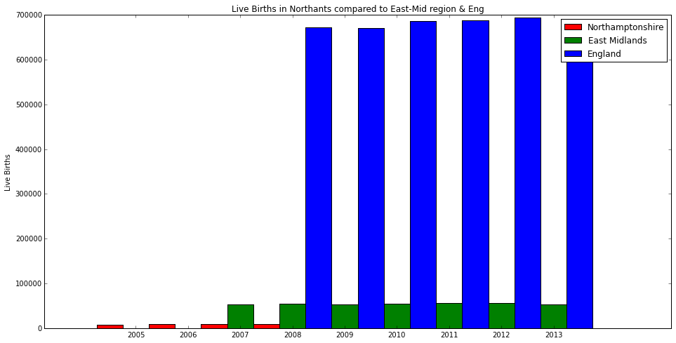

```python
fig, ax = plt.subplots()
width = 0.5       # the width of the bars

fig.set_size_inches(16, 8)

make_bar_chart(df=infants_county,
               col_regex=reg_births,
               ax=ax,
               width=width,
               title='Live Births in Northants compared to East-Mid region & Eng',
               ylabel='Live Births')

ax
```

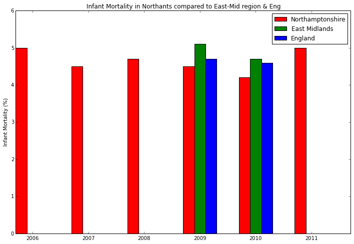

```python
fig, ax = plt.subplots()
width=0.2
fig.set_size_inches(12, 8)
make_bar_chart(df=infants_county,
               col_regex=reg_deaths,
               ax=ax,
               width=width,
               title='Infant Mortality in Northants compared to East-Mid region & Eng',
               ylabel='Infant Mortality (%)')

ax
```

## 6 Conclusions

- The demographics data provided by the Northamptonshire County provide a useful starting point for understanding the community in question. The way the data is organized on the website is of special interest to us, as a guide on how to organize the datasets we collect data from our investigations. This is important as the datasets we collect would originate from multiple datasources & social media platforms (facebook, twitter, linkedin etc.), and would need to be collated across different facets (eg professional info, activities, education etc.). So, some prior thought on organizing these datasets would benefit us in the long run.
- The DataFetcher API provides a programmatic interface for accessing the datasets on the council website and downloading them to local storage. Going ahead, the DataFetcher (or something equivalent) could be integrated with social-media crawlers and database backend storage (e.g. a document store such as mongodb) to serve as a layer of storage abstraction for any analysis/ML tools we may need to build.
- IPython notebooks can be very useful for quickly protyping any data-science ideas or tricks we may want to exchange, and also as a tool for literate programming. Although this notebook was authored in Python, the Jupyter/IPython project supports other data-centric languages such as R & Julia as well.